# Predict Number of Future Elk Hunters

Pierre Sarnow

Mon Aug 13 11:12:53 2018

## Description

Use historical Draw Results, and number of hunters to train a model we can use to predict the number of future hunters.

TODO - Include other potential inputs that could impact how many hunters get a license and show up. Those could include economic indicators, and costs associated with hunting (transportation, lodging).

**NOTICE** that I am only looking at the general rifle hunting seasons on public land. There are also hunters for Archery, Muzzleloader, Private Land, Ranching for Wildlife, etc.

## Setup

Load required libraries for wrangling data, charting, and mapping

```r
library(plyr,quietly = T) # data wrangling
library(dplyr,quietly = T) # data wrangling
library(ggplot2, quietly = T) # charting
library(ggthemes,quietly = T) # so I can add the highcharts theme and palette
library(scales,quietly = T) # to load the percent function when labeling plots
library(caret,quietly = T) # classification and regression training
```

Set our preferred charting theme

```r
theme_set(theme_minimal()+theme_hc()+theme(legend.key.width = unit(1.5, "cm")))
```

Run script to get hunter data

```r
source('~/_code/colorado-dow/datasets/Colorado Elk Harvest Data.R', echo=F)
```

Table of the harvest data

```r
COElkRifleAll
```

| Unit | Harvest.Antlered | Hunters.Antlered | Success.Antlered | Season | HuntCode | Harvest.Antlerless | Hunters.Antlerless | Success.Antlerless | Hunters.Either | Success.Either | Year |
| --- | --- | --- | --- | --- | --- | --- | --- | --- | --- | --- | --- |
| 1 | 0 | 0 | NA | 1 | EM001O1R | NA | NA | NA | NA | NA | 2006 |
| 2 | 0 | 0 | NA | 1 | EM002O1R | NA | NA | NA | NA | NA | 2006 |
| 201 | 0 | 0 | NA | 1 | EM201O1R | NA | NA | NA | NA | NA | 2006 |
| 3 | 0 | 0 | NA | 1 | EM003O1R | NA | NA | NA | NA | NA | 2006 |
| 301 | 0 | 0 | NA | 1 | EM301O1R | NA | NA | NA | NA | NA | 2006 |
| 4 | 0 | 0 | NA | 1 | EM004O1R | NA | NA | NA | NA | NA | 2006 |
| 441 | 0 | 0 | NA | 1 | EM441O1R | NA | NA | NA | NA | NA | 2006 |
| 5 | 0 | 0 | NA | 1 | EM005O1R | NA | NA | NA | NA | NA | 2006 |
| 6 | 0 | 0 | NA | 1 | EM006O1R | NA | NA | NA | NA | NA | 2006 |
| 7 | 18 | 210 | 9 | 1 | EM007O1R | NA | NA | NA | NA | NA | 2006 |

[output cut: 9990 more lines]

Run script to get draw data

```r
source('~/_code/colorado-dow/datasets/Elk Drawing Summaries.R', echo=F)
```

Table of the data

```r
COElkDrawAll
```

| HuntCode | Orig_Quota | Ttl_Chce_1 | Chcs_Drawn | Sex | Unit | Season | Year | Draw_Success |
| --- | --- | --- | --- | --- | --- | --- | --- | --- |
| EE003O1R | 1075 | 2188 | 1075 | Either | 3 | 1 | 2006 | 0.49131627 |
| EE003O4R | 300 | 533 | 300 | Either | 3 | 4 | 2006 | 0.56285178 |
| EE004O4R | 150 | 235 | 150 | Either | 4 | 4 | 2006 | 0.63829787 |
| EE005O4R | 10 | 33 | 10 | Either | 5 | 4 | 2006 | 0.30303030 |
| EE006O1R | 100 | 168 | 100 | Either | 6 | 1 | 2006 | 0.59523810 |
| EE006O4R | 80 | 83 | 80 | Either | 6 | 4 | 2006 | 0.96385542 |
| EE011O1R | 4500 | 5073 | 4500 | Either | 11 | 1 | 2006 | 0.88704908 |
| EE011O4R | 420 | 533 | 420 | Either | 11 | 4 | 2006 | 0.78799250 |
| EE012O4R | 445 | 472 | 445 | Either | 12 | 4 | 2006 | 0.94279661 |
| EE014O1R | 75 | 204 | 75 | Either | 14 | 1 | 2006 | 0.36764706 |

[output cut: 6387 more lines]

```r
source('~/_code/colorado-dow/datasets/Colorado GMUnit and Road data.R', echo=F)
```

Take a peak at the boundary data

```r
head(Unitboundaries2)
```

|  | id | long | lat | order | hole | piece | group | COUNTY | DEERDAU | ELKDAU | ANTDAU | MOOSEDAU | BEARDAU | LIONDAU | SQ_MILES | ACRES | SHAPE_area | SHAPE_len | Unit |
| --- | --- | --- | --- | --- | --- | --- | --- | --- | --- | --- | --- | --- | --- | --- | --- | --- | --- | --- | --- |
| 1 | 1 | -109.0486 | 40.83476 | 1 | FALSE | 1 | 1.1 | MOFFAT | D-1 | E-47 | A-11 | M-99 | B-15 | L-1 | 127.2227 | 81422.53 | 329506619 | 100751.7 | 1 |
| 2 | 1 | -109.0472 | 40.83357 | 2 | FALSE | 1 | 1.1 | MOFFAT | D-1 | E-47 | A-11 | M-99 | B-15 | L-1 | 127.2227 | 81422.53 | 329506619 | 100751.7 | 1 |
| 3 | 1 | -109.0460 | 40.83295 | 3 | FALSE | 1 | 1.1 | MOFFAT | D-1 | E-47 | A-11 | M-99 | B-15 | L-1 | 127.2227 | 81422.53 | 329506619 | 100751.7 | 1 |
| 4 | 1 | -109.0449 | 40.83228 | 4 | FALSE | 1 | 1.1 | MOFFAT | D-1 | E-47 | A-11 | M-99 | B-15 | L-1 | 127.2227 | 81422.53 | 329506619 | 100751.7 | 1 |
| 5 | 1 | -109.0438 | 40.83204 | 5 | FALSE | 1 | 1.1 | MOFFAT | D-1 | E-47 | A-11 | M-99 | B-15 | L-1 | 127.2227 | 81422.53 | 329506619 | 100751.7 | 1 |
| 6 | 1 | -109.0423 | 40.83181 | 6 | FALSE | 1 | 1.1 | MOFFAT | D-1 | E-47 | A-11 | M-99 | B-15 | L-1 | 127.2227 | 81422.53 | 329506619 | 100751.7 | 1 |

Move back to predictive analytics directory

```r
setwd("~/_code/colorado-dow/phase III - predictive analytics")
```

## Organize data

Will start by grouping all of the seasons together, and modeling the number of hunters per Year and Unit Group Draw results data by Year and Unit

```r
COElkDraw <- summarise(group_by(COElkDrawAll,Year,Unit),
                       Quota = sum(Orig_Quota,na.rm = T),
                       Drawn = sum(Chcs_Drawn,na.rm = T))
```

Appropriate field classes for model training

```r
COElkDraw$Year <- as.numeric(COElkDraw$Year)
```

Group Hunter data by Year and Unit

```r
COElkHunters <- summarise(group_by(COElkRifleAll,Year,Unit),
                          Hunters = sum(c(Hunters.Antlered,Hunters.Antlerless,Hunters.Either),na.rm = T))

COElkHunters$Year <- as.numeric(COElkHunters$Year)
```

Join in Hunter and Draw data together

```r
COElkHunters <- left_join(COElkHunters, COElkDraw, by = c("Year","Unit"))
```

Replace the draw data that don’t have entries with 0

```r
COElkHunters$Drawn[is.na(COElkHunters$Drawn)] <- 0
COElkHunters$Quota[is.na(COElkHunters$Quota)] <- 0
```

```r
data_index <- sample(1:nrow(COElkHunters),size = .75*nrow(COElkHunters),replace = F)
traindata <- COElkHunters[ data_index, ]
testdata <- COElkHunters[-data_index, ]
```

Save off for importing into AzureML

```r
write.csv(COElkHunters,file = "~/_code/colorado-dow/datasets/COElkHunters.csv",row.names = F)

fitControl <- trainControl(
  method = "repeatedcv",
  number = 4, #4
  repeats = 10, #20
  # classProbs = TRUE,
  # savePred = TRUE,
  allowParallel = TRUE,
  summaryFunction = defaultSummary)

HuntersModel = train(Hunters ~ ., data = COElkHunters,
                     method = "cubist", #cubist
                     # preProc = c("center", "scale"),
                     tuneLength = 10,
                     trControl = fitControl)

HuntersModel
```

```
## Cubist
##
## 1545 samples
##    4 predictor
##
## No pre-processing
## Resampling: Cross-Validated (4 fold, repeated 10 times)
## Summary of sample sizes: 1161, 1159, 1158, 1157, 1160, 1158, ...
## Resampling results across tuning parameters:
##
##   committees  neighbors  RMSE      Rsquared   MAE
##    1          0          586.9534  0.5999178  397.8220
##    1          5          224.9205  0.9398073  128.9872
##    1          9          246.6872  0.9278511  150.1643
##   10          0          514.0880  0.6954395  347.4668
##   10          5          166.4006  0.9677337  106.3225
##   10          9          191.3568  0.9578038  124.5914
##   20          0          511.7645  0.6987695  344.9094
##   20          5          164.6071  0.9683752  105.1661
##   20          9          189.1513  0.9587095  123.1323
##
## RMSE was used to select the optimal model using the smallest value.
## The final values used for the model were committees = 20 and neighbors = 5.
```

Important predictors

```r
ImpPred <- varImp(HuntersModel,scale = T)
ImpPred
```

```
## cubist variable importance
##
##   only 20 most important variables shown (out of 137)
##
##         Overall
## Quota    100.00
## Drawn     80.35
## Unit81    42.77
## Unit64    38.73
## Unit29    38.15
## Unit201   35.26
## Unit181   34.10
## Year      33.53
## Unit191   32.37
## Unit20    32.37
## Unit57    32.37
## Unit69    31.79
## Unit9     31.79
## Unit46    31.79
## Unit50    30.64
## Unit391   30.06
## Unit42    29.48
## Unit10    29.48
## Unit61    28.32
## Unit62    28.32
```

```r
# check performance
predictdata <- predict(HuntersModel, testdata)

postResample(pred = predictdata, obs = testdata$Hunters)
```

```
##       RMSE   Rsquared        MAE
## 93.3524370  0.9906379 61.2434078
```

```r
# svmRadial RMSE=427
# svmLinear RMSE=363
# cubist RMSE=104
```

We can iterate the above model by tweaking preprocessing parameters, and model algorithms. Chart performance of predicted

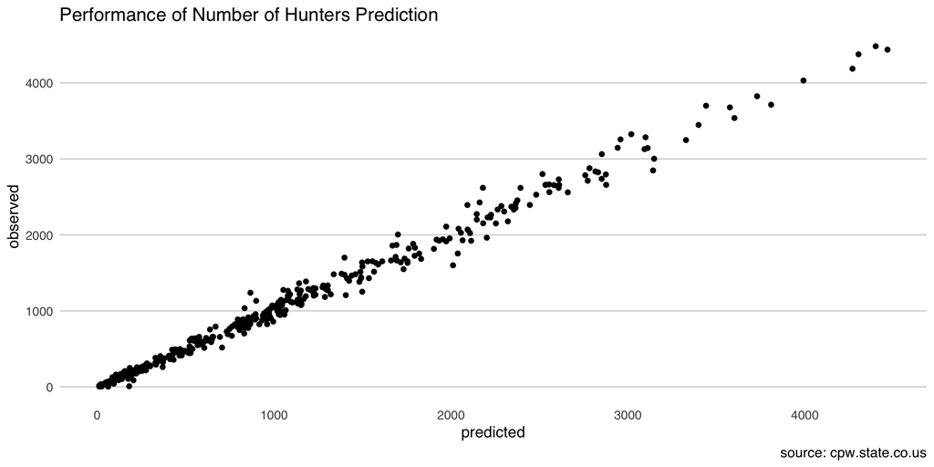

```r
chartperformance <- data.frame(predicted = predictdata, observed = testdata$Hunters)

ggplot(chartperformance, aes(predicted,observed)) +
  geom_point() +
  labs(title="Performance of Number of Hunters Prediction", caption="source: cpw.state.co.us")
```

After final model type and tuning params have been identified, run the full dataset to utilize in predicting future data. Finalize model with full dataset to train on

```r
FinalHuntersmodel = train(Hunters ~ ., data = COElkHunters,
                          method = "cubist",
                          # preProc = c("center", "scale"),
                          tuneLength = 10,
                          trControl = fitControl)

FinalHuntersmodel
```

```
## Cubist
##
## 1545 samples
##    4 predictor
##
## No pre-processing
## Resampling: Cross-Validated (4 fold, repeated 10 times)
## Summary of sample sizes: 1158, 1158, 1160, 1159, 1159, 1158, ...
## Resampling results across tuning parameters:
##
##   committees  neighbors  RMSE      Rsquared   MAE
##    1          0          588.7996  0.5999999  394.8392
##    1          5          229.8139  0.9363191  129.5048
##    1          9          250.9840  0.9249515  150.6363
##   10          0          514.3165  0.6965179  344.4640
##   10          5          169.8403  0.9657540  106.4905
##   10          9          192.0559  0.9567842  124.2120
##   20          0          511.0426  0.7004448  342.1568
##   20          5          165.7029  0.9674741  104.6846
##   20          9          187.7728  0.9587864  122.3443
##
## RMSE was used to select the optimal model using the smallest value.
## The final values used for the model were committees = 20 and neighbors = 5.
```

Important predictors

```r
ImpPred <- varImp(FinalHuntersmodel,scale = T)
```

Use the 2018 Draw data to predict the number of hunters in 2018

```r
COElkDraw2018 <- filter(COElkDraw, Year == 2018)
COElkHunters2018 <- COElkDraw2018[, colnames(COElkDraw2018) %in% c("Unit",FinalHuntersmodel$coefnames)]

COElkHunters2018$Hunters <- predict(FinalHuntersmodel, COElkHunters2018)

COElkHunters2018$Hunters[COElkHunters2018$Hunters<0] <- 0
```

Save off so we don’t have to recreate the model everytime we want the results

```r
save(COElkHunters2018,file="COElkHunters2018.RData")

## TODO
# paste in the hunters charts we had previously looked at
# also this dataset will be an input to determining the 2018 elk harvest
```